# Student Exploratory Data Analysis

### By Sargam Shah

In this project, I will use R and apply exploratory data analysis techniques to explore relationships in one variable to multiple variables and to explore a selected data set containing Student information for distributions, outliers, and anomalies.

The original dataset is available here: Note: Private Data. Ask the author for permissions.

I want to take a look at the key statistics, data types, summary etc. of the student data.

```
## [1] 400  21
```

```
##  [1] "SchoolNumber"          "DistrictNumber"
##  [3] "Performance_2011"      "Performance_2010"
##  [5] "Growth"                "Meals"
##  [7] "EnglishLanguage"       "Year_Round"
##  [9] "Mobility"              "ClassSize_kthru3"
## [11] "ClassSize_4thru6"      "Not_HSg"
## [13] "HSg"                   "Some_college"
## [15] "College_grad"          "Grad_school"
## [17] "Avg_education"         "Full_credentials"
## [19] "Emergency_credentials" "Enrolled"
## [21] "Free_Meal_Pct"
```

```
## 'data.frame':    400 obs. of  21 variables:
##  $ SchoolNumber         : int  906 889 887 876 888 4284 4271 2910 2899 2887 ...
##  $ DistrictNumber       : int  41 41 41 41 41 98 98 108 108 108 ...
##  $ Performance_2011     : int  693 570 546 571 478 858 918 831 860 737 ...
##  $ Performance_2010     : int  600 501 472 487 425 844 864 791 838 703 ...
##  $ Growth               : int  93 69 74 84 53 14 54 40 22 34 ...
##  $ Meals                : int  67 92 97 90 89 NA NA NA NA 29 ...
##  $ EnglishLanguage      : int  9 21 29 27 30 3 2 3 6 15 ...
##  $ Year_Round           : int  0 0 0 0 0 0 0 0 0 0 ...
##  $ Mobility             : int  11 33 36 27 44 10 16 44 10 17 ...
##  $ ClassSize_kthru3     : int  16 15 17 20 18 20 19 20 20 21 ...
##  $ ClassSize_4thru6     : int  22 32 25 30 31 33 28 31 30 29 ...
##  $ Not_HSg              : int  0 0 0 36 50 1 1 0 2 8 ...
##  $ HSg                  : int  0 0 0 45 50 8 4 4 9 25 ...
##  $ Some_college         : int  0 0 0 9 0 24 18 16 15 34 ...
##  $ College_grad         : int  0 0 0 9 0 36 34 50 42 27 ...
##  $ Grad_school          : int  0 0 0 0 0 31 43 30 33 7 ...
##  $ Avg_education        : num  NA NA NA 1.91 1.5 ...
##  $ Full_credentials     : num  76 79 68 87 87 100 100 96 100 96 ...
##  $ Emergency_credentials: int  24 19 29 11 13 0 0 2 0 7 ...
##  $ Enrolled             : int  247 463 395 418 520 343 303 1513 660 362 ...
##  $ Free_Meal_Pct        : int  2 3 3 3 3 1 1 1 1 1 ...
```

```
##   SchoolNumber DistrictNumber Performance_2011 Performance_2010 Growth
## 1          906             41              693              600     93
## 2          889             41              570              501     69
## 3          887             41              546              472     74
## 4          876             41              571              487     84
## 5          888             41              478              425     53
## 6         4284             98              858              844     14
##   Meals EnglishLanguage Year_Round Mobility ClassSize_kthru3
## 1    67               9          0       11               16
## 2    92              21          0       33               15
## 3    97              29          0       36               17
## 4    90              27          0       27               20
## 5    89              30          0       44               18
## 6    NA               3          0       10               20
##   ClassSize_4thru6 Not_HSg HSg Some_college College_grad Grad_school
```

[output cut: 20 more lines]

```
##   SchoolNumber  DistrictNumber  Performance_2011 Performance_2010
##  Min.   :  58   Min.   : 41.0   Min.   :369.0    Min.   :333.0
##  1st Qu.:1720   1st Qu.:395.0   1st Qu.:523.8    1st Qu.:484.8
##  Median :3008   Median :401.0   Median :643.0    Median :602.0
##  Mean   :2867   Mean   :457.7   Mean   :647.6    Mean   :610.2
##  3rd Qu.:4198   3rd Qu.:630.0   3rd Qu.:762.2    3rd Qu.:731.2
##  Max.   :6072   Max.   :796.0   Max.   :940.0    Max.   :917.0
##
##      Growth           Meals        EnglishLanguage   Year_Round
##  Min.   :-69.00   Min.   :  6.00   Min.   : 0.00   Min.   :0.00
##  1st Qu.: 19.00   1st Qu.: 57.00   1st Qu.: 9.75   1st Qu.:0.00
##  Median : 36.00   Median : 77.00   Median :25.00   Median :0.00
##  Mean   : 37.41   Mean   : 71.99   Mean   :31.45   Mean   :0.23
##  3rd Qu.: 53.25   3rd Qu.: 93.00   3rd Qu.:50.25   3rd Qu.:0.00
##  Max.   :134.00   Max.   :100.00   Max.   :91.00   Max.   :1.00
##                   NA's   :85
##     Mobility     ClassSize_kthru3 ClassSize_4thru6    Not_HSg
##  Min.   : 2.00   Min.   :-21.00   Min.   :20.00    Min.   :  0.00
##  1st Qu.:13.00   1st Qu.: 18.00   1st Qu.:27.00    1st Qu.:  4.00
##  Median :17.00   Median : 19.00   Median :29.00    Median : 14.00
##  Mean   :18.25   Mean   : 18.55   Mean   :29.69    Mean   : 21.25
##  3rd Qu.:22.00   3rd Qu.: 20.00   3rd Qu.:31.00    3rd Qu.: 34.00
##  Max.   :47.00   Max.   : 25.00   Max.   :50.00    Max.   :100.00
##  NA's   :1       NA's   :2        NA's   :3
##       HSg          Some_college    College_grad    Grad_school
##  Min.   :  0.00   Min.   : 0.00   Min.   :  0.0   Min.   : 0.000
##  1st Qu.: 17.00   1st Qu.:12.00   1st Qu.:  7.0   1st Qu.: 1.000
##  Median : 26.00   Median :19.00   Median : 16.0   Median : 4.000
##  Mean   : 26.02   Mean   :19.71   Mean   : 19.7   Mean   : 8.637
##  3rd Qu.: 34.00   3rd Qu.:28.00   3rd Qu.: 30.0   3rd Qu.:10.000
##  Max.   :100.00   Max.   :67.00   Max.   :100.0   Max.   :67.000
##
##  Avg_education   Full_credentials Emergency_credentials    Enrolled
##  Min.   :1.000   Min.   :  0.42   Min.   : 0.00         Min.   : 130.0
##  1st Qu.:2.070   1st Qu.:  0.95   1st Qu.: 3.00         1st Qu.: 320.0
##  Median :2.600   Median : 87.00   Median :10.00         Median : 435.0
##  Mean   :2.668   Mean   : 66.06   Mean   :12.66         Mean   : 483.5
##  3rd Qu.:3.220   3rd Qu.: 97.00   3rd Qu.:19.00         3rd Qu.: 608.0
##  Max.   :4.620   Max.   :100.00   Max.   :59.00         Max.   :1570.0
##  NA's   :19
##  Free_Meal_Pct
##  Min.   :1.000
##  1st Qu.:1.000
##  Median :2.000
##  Mean   :2.015
##  3rd Qu.:3.000
##  Max.   :3.000
##
```

I can see a lot of negative values in Class Size, Growth, and a lot of NAs in varoius fields. After cleaning the data, lets see the stats.

```
##   SchoolNumber  DistrictNumber  Performance_2011 Performance_2010
##  Min.   :  58   Min.   : 41.0   Min.   :369.0    Min.   :333.0
##  1st Qu.:1742   1st Qu.:395.0   1st Qu.:526.5    1st Qu.:482.0
##  Median :3004   Median :401.0   Median :643.0    Median :599.0
##  Mean   :2884   Mean   :456.8   Mean   :647.0    Mean   :606.6
##  3rd Qu.:4144   3rd Qu.:630.0   3rd Qu.:758.5    3rd Qu.:726.0
##  Max.   :6072   Max.   :796.0   Max.   :940.0    Max.   :917.0
##
##      Growth           Meals        EnglishLanguage   Year_Round
##  Min.   :  1.00   Min.   :  6.00   Min.   : 0.00   Min.   :0.0000
##  1st Qu.: 23.50   1st Qu.: 57.00   1st Qu.: 9.50   1st Qu.:0.0000
##  Median : 38.00   Median : 76.50   Median :25.00   Median :0.0000
##  Mean   : 40.47   Mean   : 71.84   Mean   :31.35   Mean   :0.2426
##  3rd Qu.: 55.50   3rd Qu.: 94.00   3rd Qu.:50.50   3rd Qu.:0.0000
##  Max.   :134.00   Max.   :100.00   Max.   :91.00   Max.   :1.0000
##                   NA's   :75
##     Mobility    ClassSize_kthru3 ClassSize_4thru6    Not_HSg
##  Min.   : 2.0   Min.   :14.00    Min.   :20.0     Min.   :  0.00
##  1st Qu.:13.0   1st Qu.:18.00    1st Qu.:27.0     1st Qu.:  3.00
##  Median :18.0   Median :19.00    Median :29.0     Median : 14.00
##  Mean   :18.3   Mean   :19.15    Mean   :29.6     Mean   : 21.22
##  3rd Qu.:22.0   3rd Qu.:20.00    3rd Qu.:31.0     3rd Qu.: 36.00
##  Max.   :47.0   Max.   :25.00    Max.   :50.0     Max.   :100.00
##
##       HSg          Some_college    College_grad     Grad_school
##  Min.   :  0.00   Min.   : 0.00   Min.   :  0.00   Min.   : 0.000
##  1st Qu.: 16.00   1st Qu.:12.00   1st Qu.:  6.00   1st Qu.: 1.000
##  Median : 26.00   Median :18.00   Median : 17.00   Median : 4.000
##  Mean   : 25.89   Mean   :19.29   Mean   : 19.78   Mean   : 8.771
##  3rd Qu.: 34.00   3rd Qu.:27.00   3rd Qu.: 30.00   3rd Qu.:10.500
##  Max.   :100.00   Max.   :67.00   Max.   :100.00   Max.   :67.000
##
##  Avg_education   Full_credentials Emergency_credentials    Enrolled
##  Min.   :1.000   Min.   :  0.42   Min.   : 0.00         Min.   : 130.0
##  1st Qu.:2.060   1st Qu.:  0.90   1st Qu.: 3.00         1st Qu.: 324.0
##  Median :2.600   Median : 87.00   Median :10.00         Median : 436.0
##  Mean   :2.673   Mean   : 64.85   Mean   :12.72         Mean   : 488.5
##  3rd Qu.:3.240   3rd Qu.: 97.00   3rd Qu.:19.00         3rd Qu.: 611.5
##  Max.   :4.620   Max.   :100.00   Max.   :53.00         Max.   :1570.0
##  NA's   :19
##  Free_Meal_Pct
##  Min.   :1.000
##  1st Qu.:1.000
##  Median :2.000
##  Mean   :2.019
##  3rd Qu.:3.000
##  Max.   :3.000
##
```

```
## [1] 371  21
```

```
## [1] 222  21
```

```
## [1] 149  21
```

I also split the data into training and testing by 60:40 ratio. Thus there are 222 records in the training set and 149 records in the testing set.

## Univariate Analysis

### Lets see what is the class size that most schools prefer.

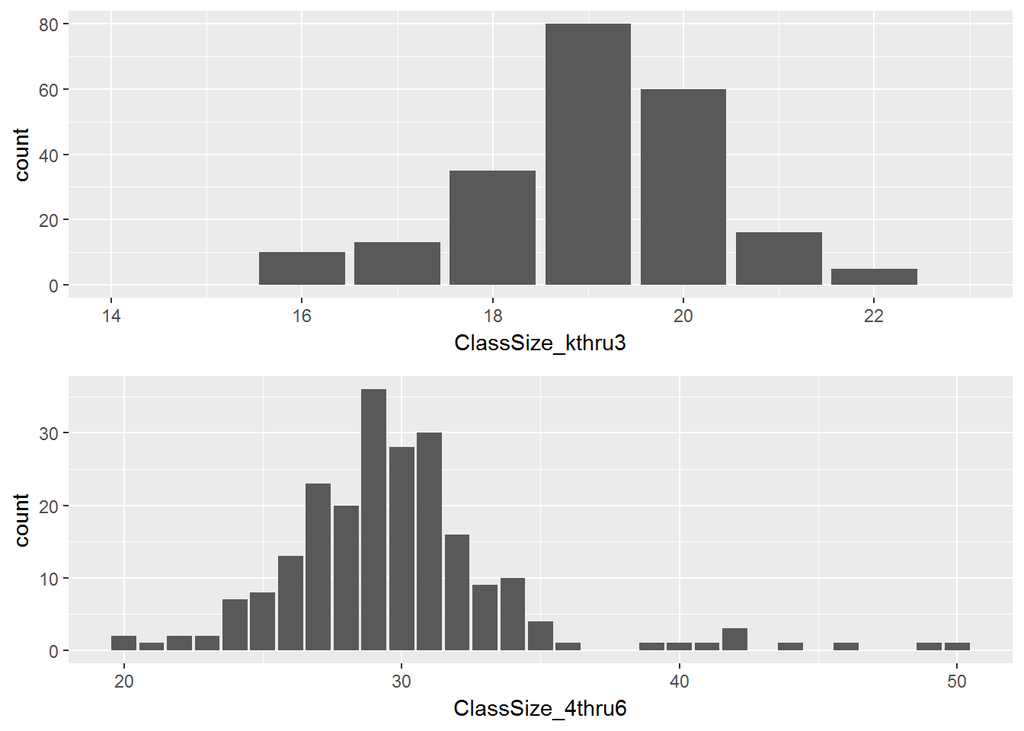

## Bivariate Analysis

Lets go through the nature of the parents who enroll their students in the schools. We have parents who are high school graduates, not high school graduates, who had gone to grad school, who went to some school.

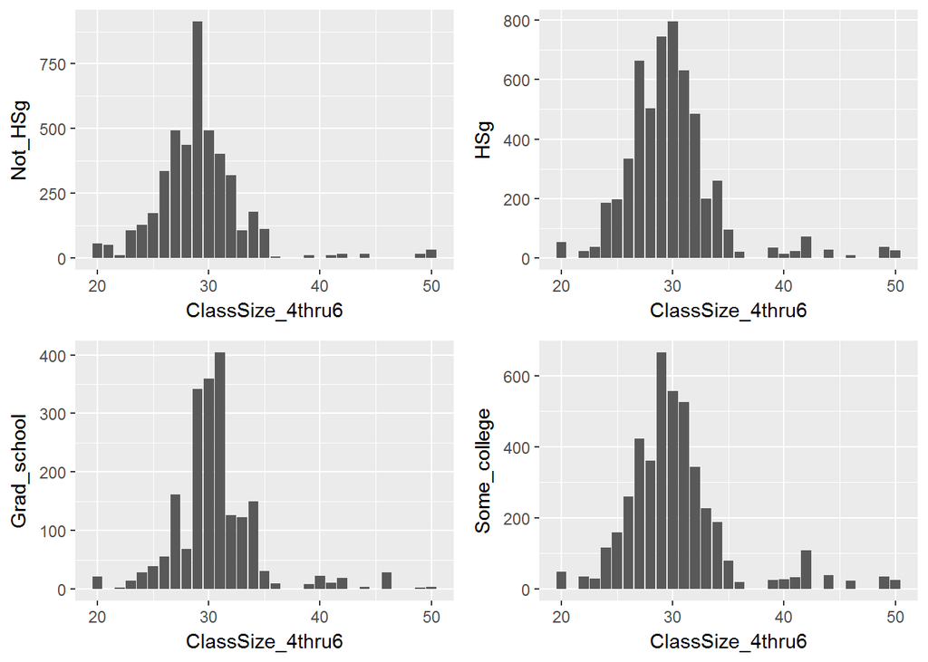

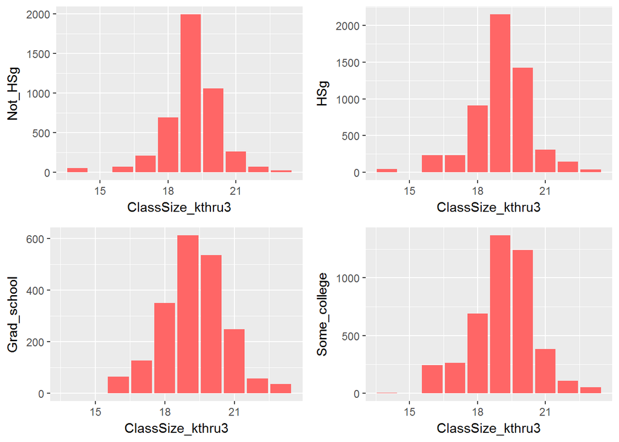

It can be seen that parents, whether they are High school graduates or College graduates, prefer smaller classes for their children whether they are kindergarden through third grade or fourth through sixth. For kindergarden through 3, the class size expected is 18 to 21. For 4th to 6th grade, any class size between 23 to 35 is expected. There are hardly any parents who prefer class size of 36 to 50. It is highly discouraged for a school to have a class size greater than 35.

### Let us see how the class size affects the performance.

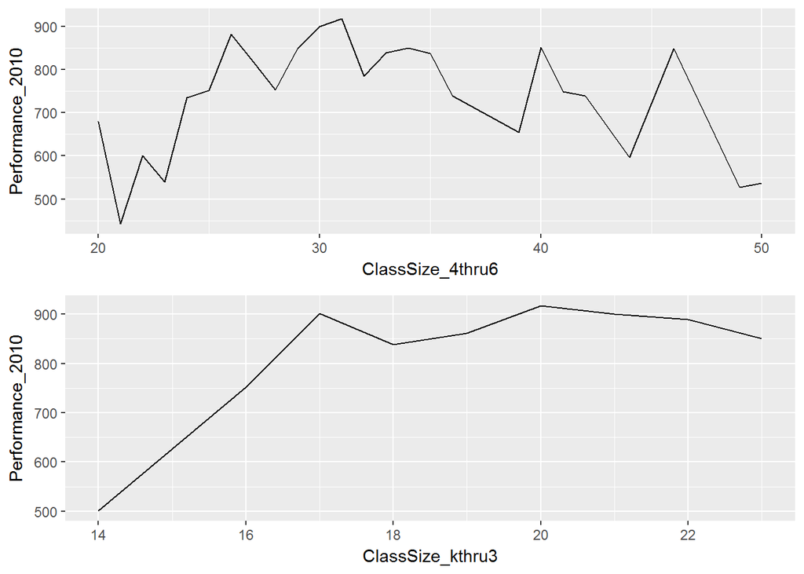

It can be concluded that, for class size 4 through 6, ther is a sharp decrease in performance as calss size goes beyond 45.

For class size k through 3, for very small class size of 14, the performance is very low. However, there is a steep surge in performance from class size 16 and it continues till 20. For larger class sizes than 20, the performance start to decline.

### Let us take a look at how it affects the growth.

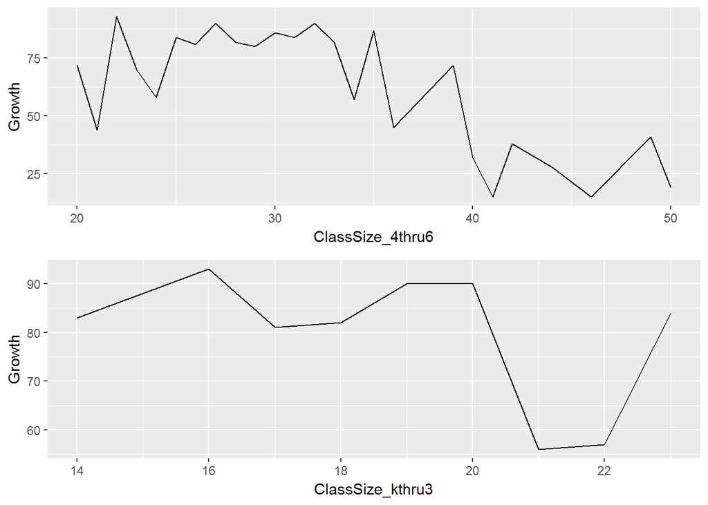

You can see similar results. As the class size increases, the growth of the student decreases with a greater rate.

### Let us check whether a school belonging to a certain district affects our findings.

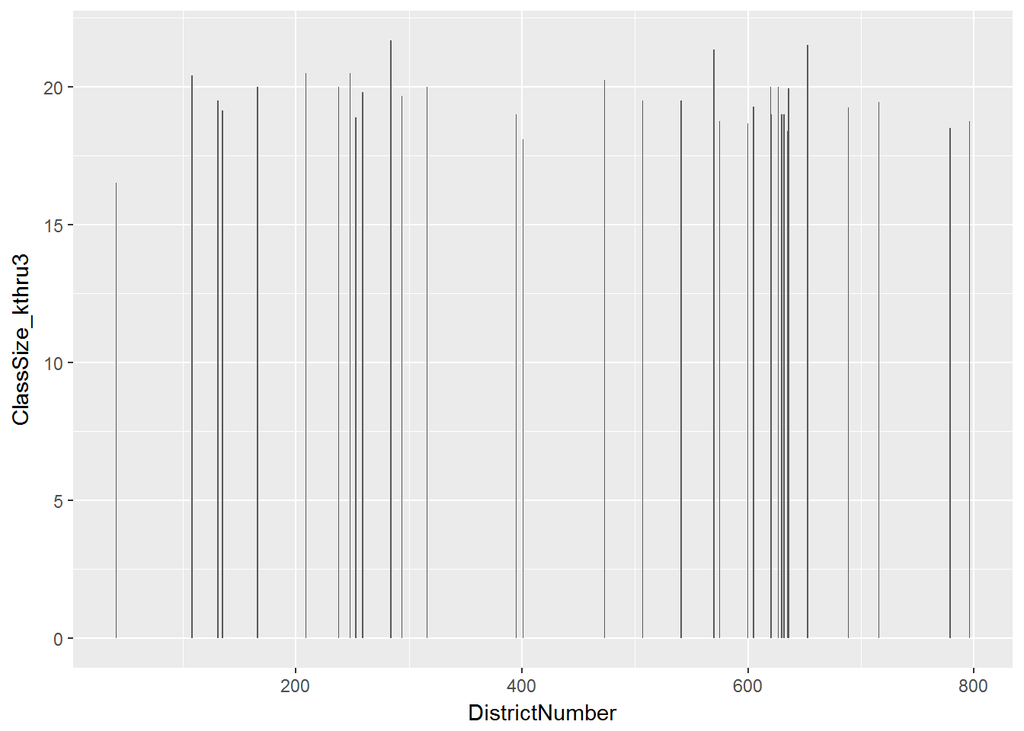

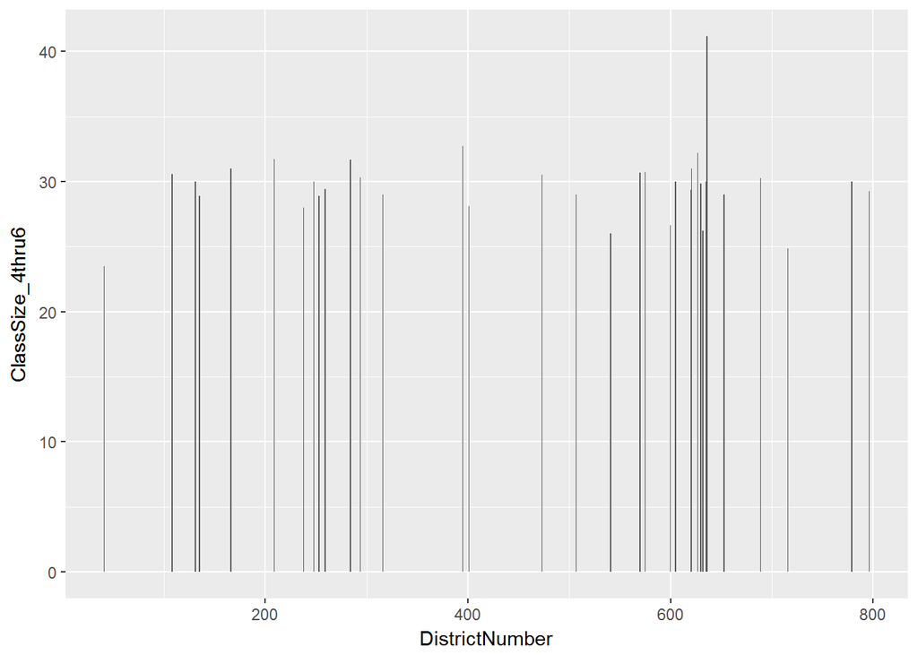

Since there are many district levels, we got so many bars. However, we can see there is no abrubt decline in the bar lengths. Thus, there is no particular district that opposes our findings to a great extent.

## Validation:

I have split the dataset into training and testing in order to prove the results. Let us generate our graphs on the testing data.

### Univariate Analysis

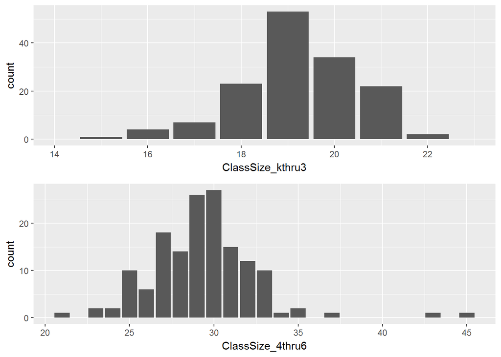

### Bivariate Analysis

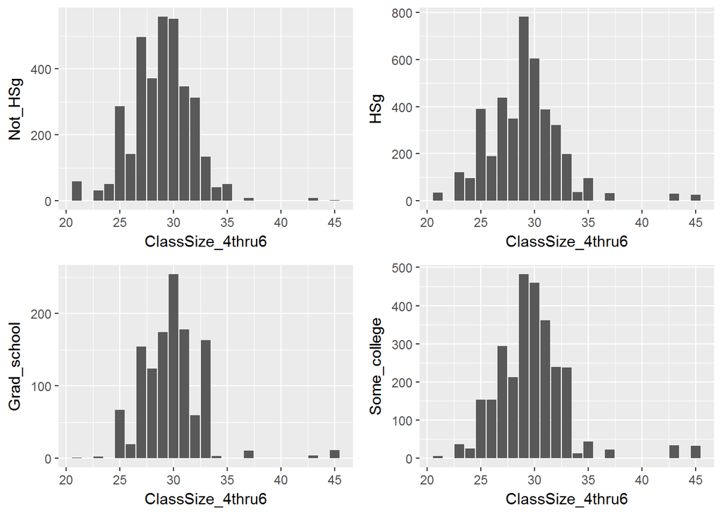

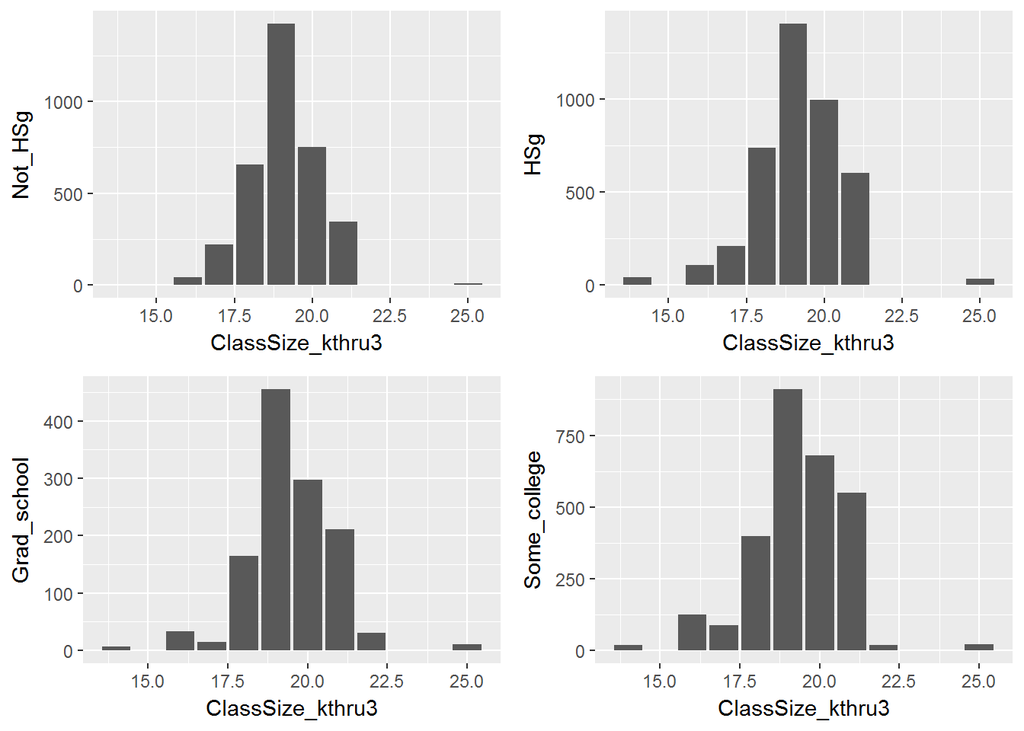

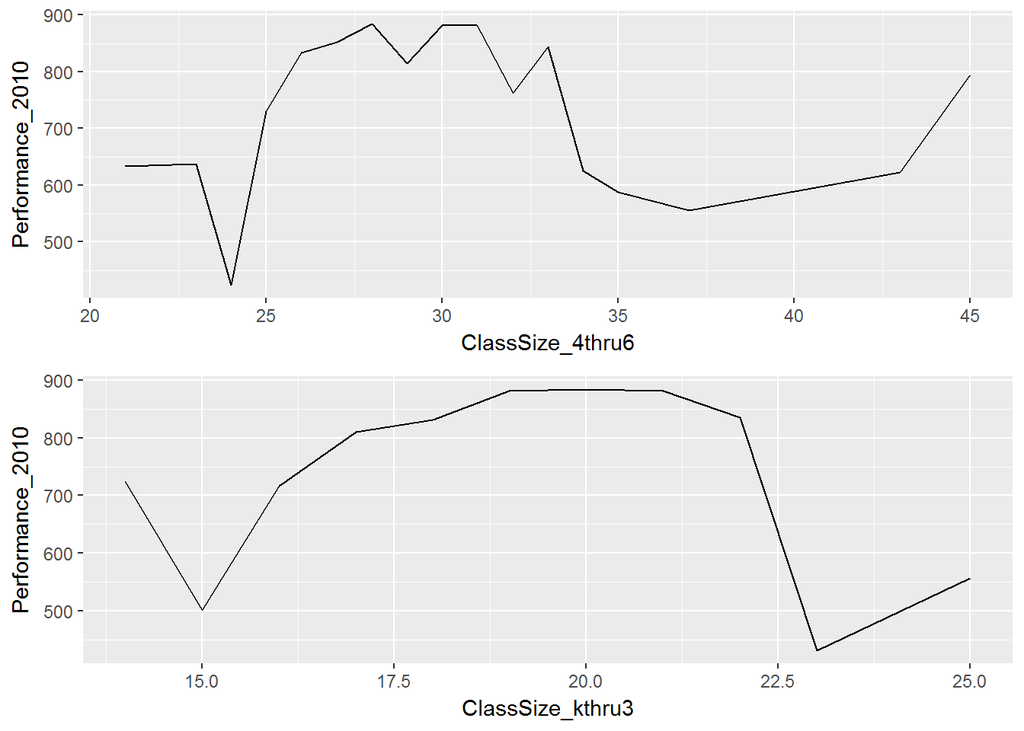

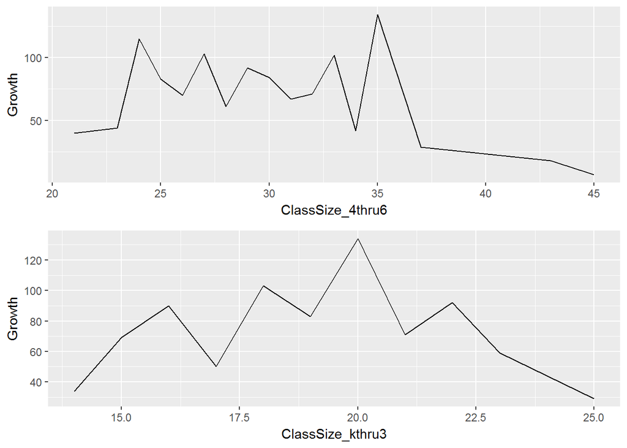

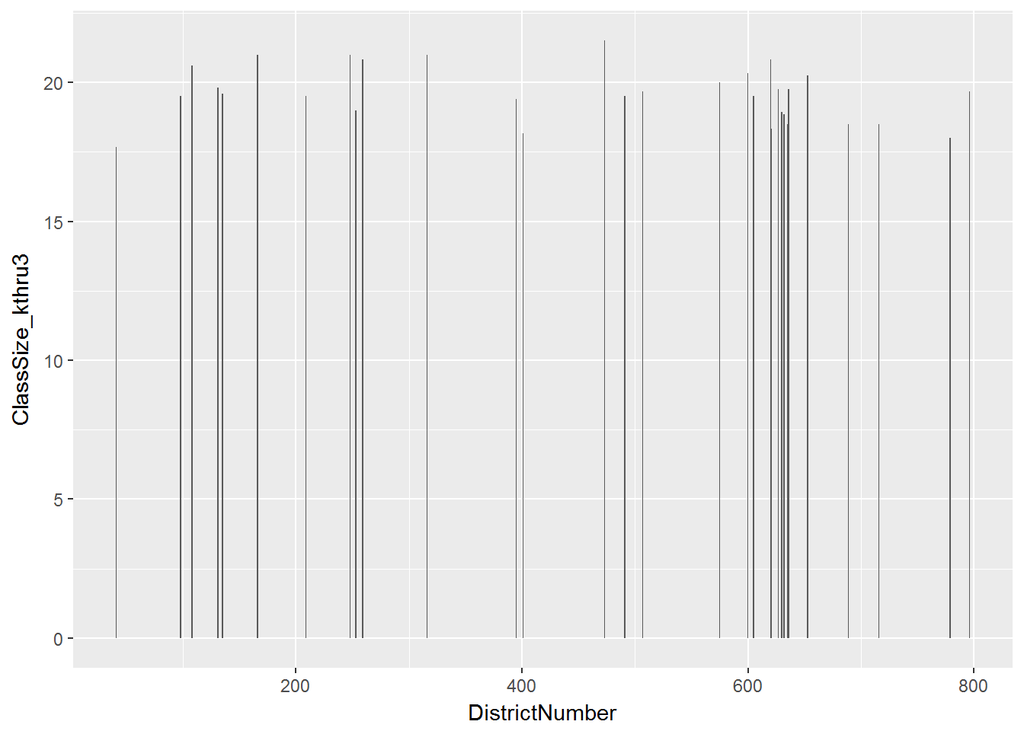

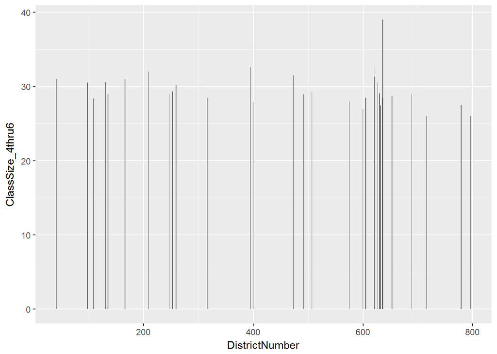

## Conclusion:

#### The preferred class size for students in kindergarden through grade 3 is 18 to 21.

#### The preferred class size for students from grade 4 through 6 is 23 through 35.

#### However, a class size of 29 is highly preferred.